Tholonia - 011-THOLON  
The Existential Mechanics of Awareness  
Duncan Stroud  
Published: January 15, 2020  
Updated: Updated: Mar 26, 2026 v8.0.89  
Welkin Wall Publishing  
ISBN-10:  
ISBN-13: 978-1-6780-2532-8  
Copyright ©2020 Duncan Stroud CC BY-NC-SA 4.0

This book is an open sourced book. This means that anyone can contribute changes or updates. Instructions and more information at https://tholonia.github.io/the-book (or contact the author at duncan.stroud@gmail.com). This book and its on-line version are distributed under the terms of the Creative Commons Attribution-Noncommercial-ShareAlike 4.0 International (CC BY-NC-SA 4.0) license, with the additional proviso that the right to publish it on paper for sale or other for-profit use is reserved to Duncan Stroud and authorized agents thereof. A reference copy of this license may be found at https://creativecommons.org/licenses/by-nc-sa/4.0/. The above terms include the following: Attribution - you must give appropriate credit, provide a link to the license, and indicate if changes were made. You may do so in any reasonable manner, but not in any way that suggests the licensor endorses you or your use. Noncommercial - You may not use the material for commercial purposes. Share Alike - If you remix, transform, or build upon the material, you must distribute your contributions under the same license as the original. No additional restrictions - you may not apply legal terms or technological measures that legally restrict others from doing anything the license permits. Notices - You do not have to comply with the license for elements of the material in the public domain or where your use is permitted by an applicable exception or limitation. No warranties are given. The license may not give you all of the permissions necessary for your intended use. For example, other rights such as publicity, privacy, or moral rights may limit how you use the material.

# 11: THOLON

###### From information primitives to the thologram: building the formal framework

##### **Synopsis:** Having surveyed the universal trinitarian pattern, this chapter constructs the formal tholonic model from first principles. It begins with the *info-atom* — the smallest possible unit of knowledge — and argues that it must obey the same geometric laws as physical form. Three stages of geometry trace the step-by-step construction of the tetrahedron from a single point through a line, trigram, and finally a 3D structure, with each stage introducing a new dimension of relationship. The holarchy is then reformulated as the *thologram* by reordering its three functions (Negotiation, Definition, Contribution) into a trigram and showing how connecting lines reveal hidden relationships. The N-D-C vocabulary is defined precisely, distinguishing dynamic (verb) and stable (noun) forms. The chapter concludes with the *thologram*: a self-similar, fractal hierarchy in which the properties of movement and energy — not the instances themselves — define the structure at every scale from subatomic particles to civilizations.

##### **Keywords:** info-atoms, tholon, thologram, N-D-C, Negotiation, Definition, Contribution, geometry, tetrahedron, singularity, holarchy, fractal, self-similar, knowledge primitives, dimensional progression

## Info-atoms

Chapter 10 closed by asking why the trinitarian pattern appears so reliably across every domain, and identified the tholon as the entity whose nature provides the answer. That answer begins here, at the smallest possible scale: the info-atom.

If our premise is that the smallest element of knowledge must conform to the same laws as the smallest elements of form, conceptually speaking, then we need to show how these 2D models, such as the holarchy, fit into not just a 3D model, but specifically tetrahedral structures that represent “knowledge molecules” with an ordered self-similar hierarchy where each holon is represented as a tetrahedron of information.

Our revised model of hierarchical tetrahedra will surely look and act differently from a holarchy. To avoid confusion, we will refer to these *tetrahedron holons* as *tholons* (for obvious reasons), and the holarchy of tholons as the *thologram*.

#### **Key 62:** Every tholon is an archetype.

We are working from the premise that everything that exists is a product of a stable pattern existing between different states. The simplest concept of such a duality is that of *something* and *nothing*. Not much can be said about *nothing*, but as for *something*, we do not need to imagine something that represents everything at once. Such a conception is not only beyond our ability, but also, given that everything has yet to come into existence (or, if it has, has not yet come into our context), impossible. On the contrary, we only need to imagine the simplest form of something, for example, a singular dot. A simple dot on a blank page is a diagram of the model on which this reality, and all knowledge, is based. If we conceive of an infinite void of nothingness within which exists a single point, then that point alone represents the totality of everything that exists. This single dot is often called the *singularity*. In the cosmological sense, the singularity is the point at which the known laws of physics break down, where space and time cease to exist as distinct entities and merge into an undefined state.

These singularities were predicted by Relativity and theoretically have **zero volume** and **infinite density** (and therefore infinite gravity). The cosmological singularity was the initial state of the Big Bang, and similar singularities are predicted (though not observable) at the centers of black holes.

There is another significance to the concept of singularity, and that is the *technological singularity*. This is the point at which technological growth becomes uncontrollable and irreversible; that is, technology can design and build itself, leading to exponential advancement and a superintelligence. Futurist Ray Kurzweil, Google’s Director of Engineering, predicts this moment will happen in 2045.

Both physics and the tholonic model arrive at a 0-dimensional point as the origin of all that exists. They are descriptions of the same origin event at different scopes and in different languages. Physics characterises that point by its physical properties: infinite density, infinite gravity, the boundary at which spacetime breaks down. The tholonic model characterises it by its pre-physical properties: A&I, from which energy, density, and spacetime then emerge. The two accounts are not in conflict; the tholonic model simply proposes that A&I is the more fundamental description of what that point *is*, and the physical properties are what it *becomes* as A&I begins to act. This simplest of concepts, a 0-dimensional point of A&I, can account for the holarchy, tetrahedra, magic crystals, all the laws of physics, and every form of intelligence in existence.

### Geometry I

The most effective way to describe this process of emergence from a dot to everything in existence is with the language of geometry.

> Philosophy [nature] is written in that great book, which is before our eyes – I mean the Universe – but we cannot understand it if we do not first learn the language and grasp the symbols in which it is written. The book is written in mathematical language, and the symbols are triangles, circles, and other geometrical figures, without whose help it is impossible to comprehend a single word of it; without which one wanders in vain through a dark labyrinth. **~Galileo Galilee, 1564-1642**

> It is the glory of geometry that from so few principles, fetched from without, it can accomplish so much. **~Sir Isaac Newton**

> Tao generates the One. The One generates the Two. The Two generates the Three. The Three generates all things. **~Lao Tzu, Dao De Ching**

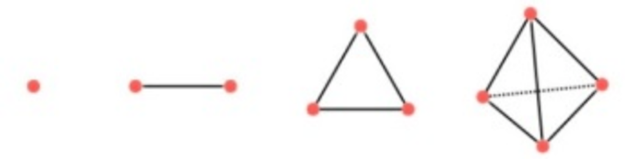

We are taught that the progression from point to tetrahedron follows a very clear and simple path of *point → line → trigram → tetrahedron*.

From the tholonic perspective, this is a very incomplete description because it treats any point as just like any other. Still, they are not the same, as each point has very different qualitative attributes. If we ignore those attributes, we are blind to what geometry can show us about so much more than shapes. Order is the most significant difference between these points, which is described below.

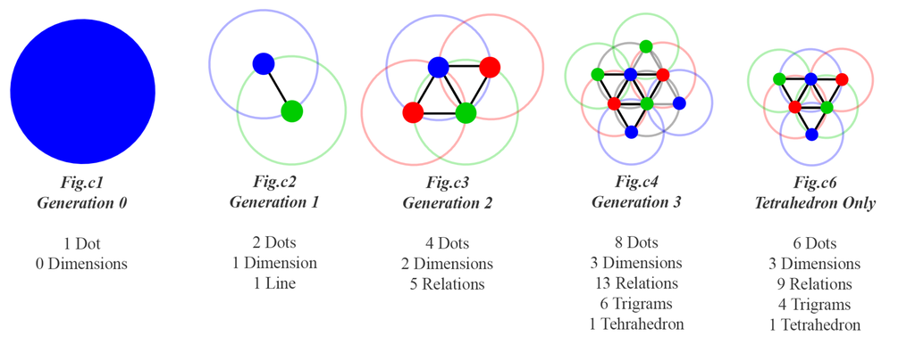

*(Unfortunately, if you are reading this on a black and white eBook reader, these color patterns are meaningless. See Appendix A, “About This Book” to test the gray scale of the primary colors on your e-reader.)*

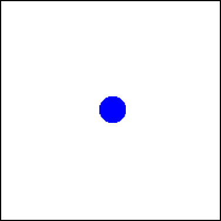

We start with a 0-dimensional dot represented by a blue dot in the middle of nothing *(**Fig. c1**)*. Because it has 0 dimensions and is surrounded by nothing, it exists only as a concept. It has no form, no spatial dimensions, no measurable properties other than the concept that it exists. But where does it exist? It cannot be measured, seen, or interacted with in any way, so how can we say it even exists? We can only say it exists because of the awareness of its existence. The only difference between pure nothingness and nothingness containing an imaginary point is the *idea* of that point itself. Without a point to be aware of, nothingness has no boundary, no reference, and no contrast. This is our first duality, that of *nothingness* and the concept of *somethingness*, and also the first condition of imbalance.

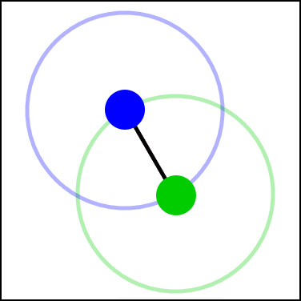

This next step requires some philosophical conjecture because we have to ask why or how does a 2<sup>nd</sup> (green) dot appear (*Fig. c2*).

If we accept the premise that everything that is created has the attributes of, and limitations of, whatever created it, then the answer is clear and simple. This lone imaginary dot in the middle of infinite nothingness exists only as an awareness of the concept of a point. Therefore, the one attribute this point must inherit is awareness itself, as that is what it was created from. Having inherited this attribute of awareness, the first dot now possesses the same creative capacity as the awareness that created it. Just as the original awareness created the first dot, the first dot’s awareness creates the second dot in precisely the same manner. And what was this awareness? We can only presume that it was the most fundamental form of awareness, that being the awareness of existing (which is not the same as the meta-awareness of being aware that one is aware). This primal first instance of awareness is therefore the archetype of all awareness that will ever come into being. Additionally, being the only awareness that exists, it is virtually *unlimited awareness*, and possibly *infinite awareness* as well if we consider “infinite” to mean the totality of all.

One might reasonably object: “How can a 0-dimensional point possess awareness?” From our three-dimensional perspective, a 0-dimensional point appears to have no properties whatsoever. However, we have already established that reality exists within a multi-dimensional framework, as evidenced by the E8 crystal structure with its 248 dimensions and the projections from higher dimensions into our observable 3D space. Just as the vast complexity of the E8 crystal can manifest as simple tetrahedral projections in three dimensions, this apparently simple 0-dimensional point could be a projection or manifestation of something far more complex when viewed from a higher-dimensional reality. Therefore, it is reasonable to propose that this point can indeed possess and inherit the properties of its creator, including awareness, even though it appears dimensionless from our limited three-dimensional perspective. Indeed, awareness itself, especially in its archetypal form, may be considered the ultimate multi-dimensional existence, far more complex and encompassing than our current three-dimensional understanding allows us to perceive.

There is one more, far less obvious attribute to consider as well, and that is *intention*. The very fact that the 0-dimensional point exists as an idea demonstrates that there must have been the intention to conceive of it. Ideas do not spontaneously appear without intentionality. So, our point in the middle of infinite nothingness has two inseparable attributes: Awareness and Intention. The nature of that intention is addressed further on.

> **A note on terminology:** Throughout this book, we use specific capitalization conventions to distinguish between the primal archetype and its manifestations. The term **A&I** refers to the uncreated primal creative force of Awareness and Intention from which all instances emerge. When we use the capitalized words **Awareness** or **Intention** individually, we refer to those primal archetypal attributes. In contrast, the lowercase terms **awareness** and **intention** refer to instances of A&I. By “instance,” we mean a sustainable pattern of energy resulting from the movement of energy within a duality. These instances include physical objects ranging from grains of sand to entire solar systems, as well as concepts and ideas. All of these are manifestations of the original A&I archetype. Importantly, even the first dot, while serving as the archetypal template for all subsequent dots, possesses lowercase awareness and intention because it is an *instance* created by the primal force, not the primal creative force itself. It is important to note that even when we use the words **awareness** or **intention** singularly, each always implies its inseparable counterpart, as Awareness and Intention cannot exist independently of one another.

#### **Key 63:** Awareness and Intention (A&I) is the source of existence.

We see this same concept, that of creation being the result of A&I, in the spiritual texts of every major belief system. For example, in the Abrahamic (Jewish, Christian, and Islamic) lore[^1], when God spoke to Moses, God was quite specific about its name. God told Moses its name was “I Am (Who/Which/That) I Am” () and also informed Moses that the voice he was hearing was (or was sent by) “I AM” ().

The phrase “I am” is especially relevant to the fundamental forms of Awareness and Intention, as “I” is the simplest concept of Awareness that can be communicated. The infinitive verb “to be” is inherently a statement of intention to exist, with its present tense form being “Am”. Quite literally, “I Am” means “Awareness and Intention”.

#### **Key 64:** “I Am” literally means the present form of “Awareness and Intention”.

Buddhists appear to have cut out the middleman (or perhaps “middle-god”), as they do not have the concept of a divine creator. Still, they do have the concept of a primal “I Am” awareness, as suggested in a Buddhist teaching: *A person asked Buddha, “Are you a God?” Buddha replied, “No.” “Are you an Angel?” “No.” “Then what are you?” “I am awake.”*

We can also see the concepts of A&I in the context of physics. Take the example of energy, mass, and light, as we briefly addressed earlier. Light has no mass, and in its archetypal state, it exists as the concept of a 0-dimensional point with zero energy. Just as a magnetic field can exist with a value of zero (an established scientific axiom), a photon can exist as an archetype with zero energy. We cannot measure such a photon, but the archetype exists as a concept. This conceptual point, a result of *awareness*, only gains measurable properties when intention manifests as movement (speed, frequency, amplitude). This movement is not the photon’s own intention, but rather an instance of the archetypal Intention that originated from the very first primal point. Movement requires energy; the movement of energy itself is an instantiation of primal Intention, making light (or any form of radiation) a primal expression of A&I. It suggests that awareness may be the purest form of energy. Still, it is intention that makes it manifest through movement. Awareness and Intention always exist as two inseparable aspects of the primal archetype, similar to how electric and magnetic fields exist as inseparable aspects of an electromagnetic field, each able to be zero yet still existing as concepts.

This may sound like we are teetering on the edge of mysticism, but this is not our goal. We are following the most reasonable path that our ability to understand our reality allows. The fact that it suggests that all of existence is a form of A&I is not mysticism; it is a hypothesis of reality. Science is slowly beginning to consider the possibility of a relationship between awareness and reality. Still, the tholonic position is that awareness is not only the fabric of reality, but that the intention of that awareness is the energy that drives all of creation and the only energy in existence. Just as the term “electrical current” implies a magnetic component, the word “awareness”, as we use it here, implies an *intention* component, as Awareness and Intention always coexist. In the reality we exist in, there is no Awareness without Intention, nor Intention without Awareness.

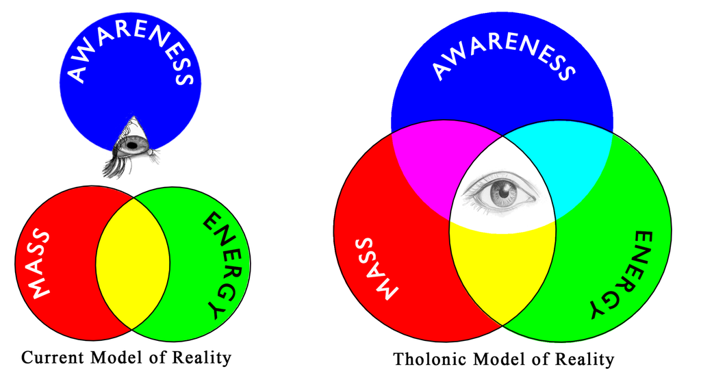

We have seen how mass is a form of energy, and how they both follow the same rules applicable to their context. Because of this, we can speculate that mass and energy are two different manifestations of the same archetype of pure energy, instantiated within two distinct scopes or contexts. We will take one step further and say that awareness itself (as we currently understand that concept) is an instance of that same archetype but in an even “finer” context, that is, before there was mass, there was energy, and before there was energy there was A&I. Were this the case, it would shed light on why and how awareness and intention is an integral part of reality, which could provide answers to the quantum mystery of how and why awareness itself is required for reality to exist, because in this scenario, everything that exists must have some instance of awareness. We accept that reality arises from the interaction between two forms of energy: radiation and mass. But what if A&I itself is a third, even more fundamental state from which energy (as we understand it) emerges?

It would be very convenient if awareness and/or intention were somehow mapable to one of the missing formulas in our hexagonal model of Newton’s 2<sup>nd</sup>, because then we could see that mass, energy, and force were connected to awareness and intention, suggesting that nothing can come into existence without A&I. We might then also be able to calculate the *field* and *force* of awareness. To be clear, I am not claiming this is the case; I am just saying it would be convenient if it were. One potential avenue of exploration might be to consider force as an expression of Intention (I), since force causes movement and change. At the same time, mass could represent Awareness (A) as the substrate or being that exists. Acceleration would then represent the manifestation (M) or result of Intention acting upon Awareness. In this hypothetical mapping, Newton’s equation F = ma could be conceptualized as $I=A\times M$, or, rearranged, $M=\frac{I}{A}$. While this remains highly speculative, such a framework might provide a mathematical language for describing how A&I manifests in physical reality, potentially bridging metaphysics and physics in ways currently unexplored.

Restating this fundamental principle: our first dot has the two attributes of A&I, and the limitation of 0-dimensions. This dot, then, is itself a form of awareness and intention, and being so, there is now an awareness of *dotness*, not *its dotness*, just *dotness*, as that is all there is to be aware of, but it is an awareness of *dotness* with intention. Just as the first dot is the effect of intentional awareness, the same intentional awareness in the newly created (blue) dot will cause a new effect: a new conceptual (green) dot. Perhaps this is what Nietzsche was referring to when he wrote in “Beyond Good and Evil”:

> And if thou gaze long into an abyss, the abyss will also gaze into thee.

The new dot, and all dots that will ever come into being have the same qualities of awareness and intention, as that is what created them, so as soon as the first dot was created, a never-ending cause-and-effect chain reaction of dots creating dots was initiated, like a kind of conceptual Big Bang. With these first 2 conceptual, 0-dimensional dots, the first relationship was created: the line. It is worth noting that even before we have a geometric triangle, we now have our first semantic triplet: two objects (the two dots) connected by a predicate (the line representing their relationship). This is the archetypal structure of all semantic triplets, the fundamental pattern by which information is organized and communicated. In this way, the structure of information itself emerges simultaneously with the first relationship, demonstrating that information and existence are inseparable.

There are now 2 states of *dotness*: the blue dot and the green dot. This is the birth of the concepts “I” vs. “Other than I”, and “Me” vs. “You”. Where before there could only exist unlimited A&I as there was nothing other than *dotness*, now there is an instance of awareness that is limited by, and defined by, another instance of awareness. This results in 2 types of awareness: the *subjective*, which is the awareness of one’s existence, and which is infinite by nature, and the *objective*, the awareness of another’s existence, which is finite by nature. Both of these states, the subjective and the objective, exist in each dot, so now there are 2 forms of awareness in 2 dots. In this way, 1 dot creates 2 dots, which in turn create 4 perspectives (this will soon be a very significant detail).

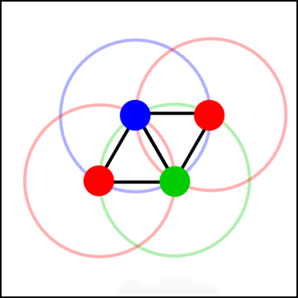

With two dots in existence, each has its own center with the other defining its limits. Where these 2 instances meet, where *subjective* meets *objective*, where the *infinite* meets the *finite*, a pair of new (red) dots emerges (*Fig. c3*), each created from the merging of these opposites.

At this stage, we have all 3 types of dots: blue, green, and red. Each of these dots came into being due to a unique cause, and each had a unique effect.

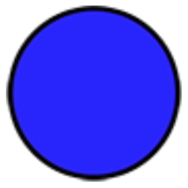

- The 1<sup>st</sup> blue dot represents the initial or parent 0-dimensional dot, the first instance created by the primal A&I. This dot cannot create dimension and exists only as a concept of awareness. This is the awareness that exists before self-awareness, as self-awareness can only exist when there is something other than itself to be aware of. Self-awareness requires an “other” awareness, a duality of awareness. This is the dot that defines the simplest form of existence as a pure instance of A&I, existing as pure potential before any manifestation. It is equivalent to the number 0, which paradoxically is both the concept of nothing and a fundamental placeholder essential to all mathematical operations. Just as 0 must exist for arithmetic to function, this first dot must exist for all subsequent creation to unfold.

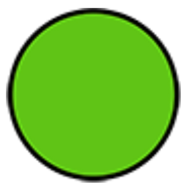

- The 2<sup>nd</sup> green dot represents the first-generation dot created by the blue dot’s instance of awareness. This dot adds 1 dimension to 0-dimensions and defines separation and division, creating the conditions for the subjective and objective, and, consequently, the idea of self-awareness as a result of one state of awareness relating to another. It is equivalent to the number 1, the first actual quantity, and the multiplicative identity. Just as 1 is the generator of all counting numbers through repetition and all rational numbers through division, the green dot is the archetype from which all subsequent instances can emerge. With 1, counting begins; with the green dot, the relationship begins. By extension, this represents all real numbers, as the entire number line can be generated from the unit of 1.

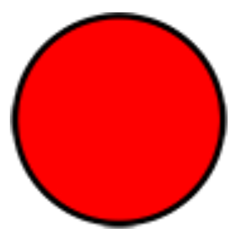

- The 3<sup>rd</sup> red dot represents where the blue dot and the green dot interact. The 3<sup>rd</sup> dot is always created as a pair, one for each of the opposite states of blue dot-green dot interactions, emerging not from a single source but from the *relationship* between the two existing dots. This dot adds 1 dimension to an existing 1-dimensional space and defines the concept of *scope* and *area* as a result of the *union*. It is equivalent to 2-dimensional numbers, or complex numbers, such as

[figure not shown]

  . Why is it related to imaginary numbers? Because we have two real numbers, 0 and 1, that create two versions of a 3<sup>rd</sup> number, as represented by the 2 red dots. This 3<sup>rd</sup> number therefore needs two values to be fully expressed, which is also the case with any real number multiplied by an imaginary number, as in *2×√-1=**2i***. Just as complex numbers enable solutions to equations that are impossible using only real numbers, the red dots enable dimensional expansion impossible with only the blue and green dots. Complex numbers require both a real and imaginary axis to exist, just as these red dots require both blue and green to emerge. (This might also be an argument why the blue dot’s value should be *i* rather than 0, making the 3rd dot value *1×√-1=**1i***).

Our ever-expanding conceptual model, however, faces a fundamental limitation: it is imprisoned in the 2D world. Even though it can generate an infinite number of dots within the 2D plane, it cannot produce a new dot that transcends into the 3D plane. Why can’t the same process that created 2D from 1D be used to create 3D from 2D?

The reason is geometric: three dot types are necessary and sufficient for defining any 2D area. Multiple instances of red, green, and blue dots can describe any 2D geometry. A 4<sup>th</sup> type constrained to 2D would be redundant, offering no dimensional expansion. We need a completely new type of dot that transcends this 2D limitation while remaining compatible with all 3 existing types.

Not surprisingly, the trigrams have already given us the answer with two clues. The 1<sup>st</sup> clue: the creation of one trigram implies the creation of three additional trigrams, each connected to a side of the center trigram. The 2nd clue: for each of these new trigrams, another dot is created. These 3 additional dots at the outer tips are each of a different color. Here is the key insight: every trigram must be composed of 3 unique dots (R, G, and B). A new type of dot capable of creating a 3D tetrahedron would automatically create 3 new trigrams. This new dot would have to act as a red dot to the blue-green pair of the original trigram, a blue dot to the green-red pair, and a green dot to the red-blue pair.

The RGB dot , or what we will refer to as the *white dot*

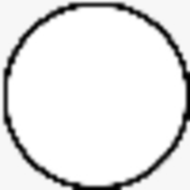

, represents the combination of all three primary dots. This dot can add 1 dimension to 2 dimensions and defines volume as a result of the union of the 3 unique trigrams that extend from the center trigram. Such a dot is created when the 3 outer trigrams fold until their points meet. The folding occurs naturally because it represents the most balanced and efficient interaction between a set of four unique dots (R, G, B, W). Energy minimization drives this configuration to emerge as the most stable state.

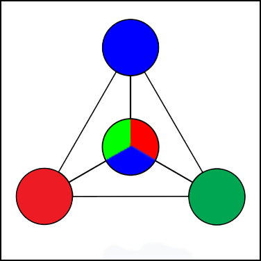

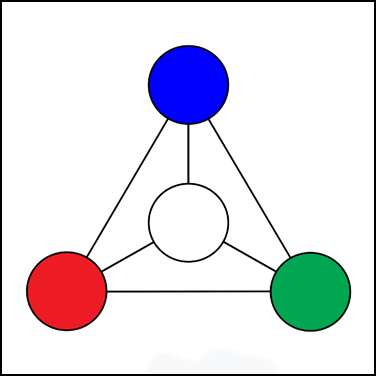

We now have a tetrahedron.

*Note: This same concept is also explained mathematically in the chapter “How Creation Works” in the book “The Tholonic I-Ching”, which examines the I-Ching from a tholonic perspective.*

## Holons to Tholons

Let us back up and apply some semantic concepts to the holarchy, as this will shed more light on the nature of information and how a holarchy forms a network of trinities through the way holons interact with one another.

We begin with a simple trigram.

According to the creators of the holarchy model, each holon has three functions:

- **Contributes** (to the context it exists within)
- **Negotiates** (with other peer contexts)
- **Defines** (that which it provides context for, its creations)

These attributes hold up quite well when compared to our real-world example of a supply chain, which includes a contributing supply, a demanding market for that supply, and the negotiations, cooperation, and competition that connect the two.

Here is where we turn a holon into a tholon: by rearranging the order, while keeping all the relationships the same, and then presenting that order in a different format.

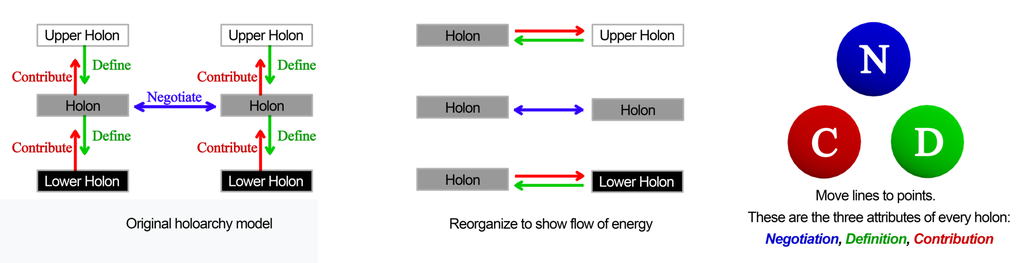

This is much more than a cosmetic change, for by changing the focus and pattern, we can see much more information. For example, we naturally want to imagine how to connect these three attributes. If we create connecting lines (demonstrated below) and color them to match the dots they emerge from, we can visualize the relationships between attributes: a red line emerging from the red dot of Contribution shows the relationship between Contribution and Negotiation (the blue dot); a green line emerging from the green dot of Definition shows the relationship between Definition and Contribution (the red dot); and a blue line emerging from the blue dot of Negotiation shows the relationship between Negotiation and Definition (the green dot). The colors we are using, red, green, and blue, are the simplest representations. However, using complementary colors for lines and dots can create very clear, more complex, and symmetrical patterns that support the model just as well.

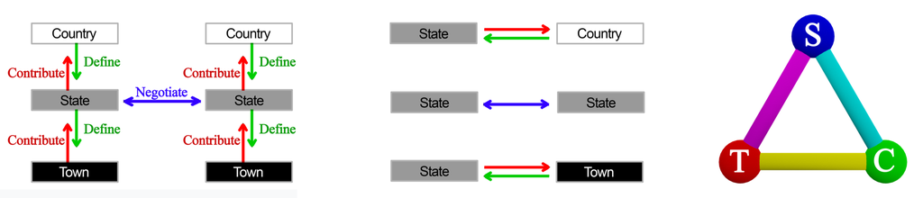

There is still a piece missing from the holarchic model. If we apply the holarchic model to the archetype concepts of *town*, *state*, and *country*, it shows only hierarchical interactions: between *state* and *country* and between *town* and *state*. It shows no direct connection between *town* and *country*. The tholonic model, however, *does* show this direct connection (the yellow line in the diagram). Note that in this diagram, we are using additive color mixing: each line’s color is generated by combining the colors of the two points it connects (yellow = red town + green country, cyan = blue state + green country, magenta = blue state + red town). If the concept of *state* is stable, then a new *state* will naturally appear across this direct town-country connection simply because it can, and if it *can*, it *must*. For example, the three towns (that is, colonies) that existed near the Delaware Bay in the newly declared United States of America eventually became the State of Delaware, the first state in the United States.

The tholonic model therefore creates a new instance of *state*, which means there are now two instances of *state*. It may seem redundant to have two instances of *state*, but in fact, they are not the same. The originating concept of *state* is that of any social structure that exists between *country* and *town*, but a *state* that exists between *town* and *country* is specific to that *town* and *country*. For example, the abstract concepts of *town*, *state*, and *country* may instantiate as *Woodstock, New York, USA*, or *Navarro, Buenos Aires, Argentina*, two radically different instances of the same *town/state/country* tholonic archetype. But this is not the most important difference between these two *states*. As described earlier, the blue Negotiated point is the only point from which children can emerge; therefore, a new negotiated point must exist for any instances to occur. That point, in this example, is the negotiated balance between *town* and *country*. Specifically, a *state* is *Defined* (limited, constrained) by its *country* and *Contributes* (allows for creation of) its *towns*. So, this new point of *state* between *town* and *country* would be an instance of the concept of a *state*, for example, the *state* of *California*. Now, *California* is itself a concept that has within it its own California-based instances of economy, politics, culture, terrain, weather, and more.

Notice in the diagram the small blue N dot that appears at the center of the yellow line connecting Contribution (red) and Definition (green). This represents a new, instantiated state of Negotiation that emerges between these two poles. Since Definition is analogous to low-entropy chaos (limitation) and Contribution is analogous to high-entropy chaos (dispersion), the yellow line connecting them forms a spectrum along which a sustainable state of order naturally emerges. This is the instantiated Negotiation point—a balanced state that appears wherever the conditions allow it, following the principle that if a stable pattern *can* exist, it *must* exist.

Hence, the final model of a 2-dimensional tholon is:

[figure not shown]

In our illustrations, we will often use the two-dimensional representation of the thologram rather than the three-dimensional one because it is simply easier to visualize. As shown in the diagram above, the two-dimensional thologram has four points but is confined to two-dimensional space. When we extend this model into three-dimensional space, the fourth point lifts out of the plane, creating a tetrahedron from what was a triangle. The 3-dimensional model is far more complex, which we get into later.

Before we continue, we must clarify some points on vocabulary, particularly the word *negotiate* and its various forms. Words can be confusing, and sentences even more so. Consider the grammatically correct sentence shown above, invented by Professor William J. Rapaport in 1972:

[figure not shown]

What this sentence is trying to say is:

> *Bison from Buffalo, New York who are intimidated by other bison in their community also happen to intimidate other bison in their community.*

The confusion comes from the fact that the word *buffalo* has several meanings: as an animal, a place in New York, and a synonym for bullying.

In English, verbs have different forms to indicate various aspects of action. The *progressive form* indicates ongoing action, the *perfect form* indicates a completed action, and the *perfect progressive form* indicates the transition between the two (that is, ongoing action that will be completed at some definite point). All these forms also have *past*, *present*, and *future* tenses.

Can verbs also function as nouns? Yes, in some cases, as with the word *balance*. The noun *balance* is defined as “a state of equilibrium”, and that same definition applies to the achieved state when we use *balance* as a verb. This is not the case with words like *run* or *drive*, as there is no present state to achieve, no final condition that driving or running results in, only a past state of *ran* or *drove*.

In some cases, even the pronunciation determines the function. The word “perfect”, when pronounced *PER-fect*, is a noun, and when pronounced *per-FECT*, it is a verb.

Given these complexities of language, let us be very clear on how we are defining the word *negotiate*.

First, understand that in this hierarchy of energy, everything is happening all the time, so when we refer to these energies, we refer to them in the present (unless otherwise noted).

In the tholonic model, the three points of a tholon can be referred to by different names, depending on whether we emphasize their dynamic processes or their stable states. These three points are:

- **Negotiate / Balance**
- **Define / Limitation**
- **Contribute / Integration**

Each of these attributes can function in two ways:

**As Actions (verb-like)**: When emphasizing the ongoing processes, we use terms like *Negotiate*, *Define*, and *Contribute*. These describe dynamic interactions occurring continuously: forces are *negotiating* or *balancing* with each other, boundaries are *defining* or *limiting* possibilities, and elements are *contributing* or *integrating* to larger patterns.

**As States (noun-like)**: When emphasizing the stable conditions that have been achieved, we use terms like *Balance*, *Limitation*, and *Integration*. A *Balanced* or *Negotiated* state represents the sustainable equilibrium that emerges from negotiation, a *Limited* or *Defined* state represents the established boundaries or constraints, and an *Integrated* or *Contributed* state represents what has been incorporated into the system.

## The Thologram

The primary reason why the properties of movement and energy are the key points in a thologram rather than the instantiated elements, as in the holarchy, is that these properties remain consistent at every level of creation. There may be millions of instances of different types of elements within the holarchy, from subatomic to universal, and everything in between, but the properties of movement and energy are always the same, even though they are expressed differently in each context. Therefore, it is the properties of movement and energy that define the structure of the hierarchy, not the instances of elements.

To further illustrate this point, we can use the previous semantic example of “Alice *is a friend of* Bob”. The tholonic model looks at “*is a friend of*” as the energetic force that defines Alice and Bob, at least within this narrow context of *friendship*. Without relationships, Alice and Bob would not even exist, as relationships define every interaction at every level of existence.

Consider the sentence *Bob is a farmer that grows corn and eats meat*. This sentence contains three semantic triplets. We can look at the relationship of the three objects (nouns): *Bob, corn, meat*, which describes Bob’s specific context. Or we can look at the relationship of the three predicates (verbs): *is a, grows, eats*, which applies to all organisms that practice agriculture or cultivation (like Leaf Cutter ants farming fungus, Fijian ants herding aphids, damselfish cultivating algae, yeti crabs farming bacteria, and humans).

These properties direct energy, energy has movement, and movement has direction. In this example, the direction is clear. However, this direction could change under different circumstances, as we will see later.

The idea of modeling reality on the movement of energy rather than the *things* themselves is not new. The *Reciprocal System theory* is built on the same premise and provides the best explanation of why we are using the movement of energy in the relationships and not the contexts of where that energy is coming from or going to.

> The thesis of the Reciprocal System, however, is that the Universe is not a Universe of matter. Still, a Universe of motion, one in which the basic reality is motion, and all entities - photons, particles, atoms, fields, forces, and all forms of energy - are merely manifestations of motion.[^2]

Like every theory, it has its fans and its critics. In any case, it applies perfectly here.

Newton’s laws of Motion are similar in this regard, as the laws of motion describe the energy that relates to mass, not any particular instance of mass. Because of this, we can show a direct relationship between these tholonic concepts and Newton’s laws.

- **Newton’s 1<sup>st</sup> law states** *“Every object in a state of uniform motion will remain in that state of motion unless an external force acts on it”.*

  This law introduces the concept of an instance of mass and its inherent limitation: an object cannot change its state of motion without an external force acting on it. This inability to self-change puts it in the realm of the 2<sup>nd</sup> green dot and the tholonic concept of *Definition* or *Limitation*. The concept of *inertia* is defined here as the property that restricts how mass responds to force.
- **Newton’s 2<sup>nd</sup> law states** *“Force equals mass times acceleration”.*

  *Force* is the product of mass and acceleration (F=ma), combining the property of matter (mass) with the rate of change of motion (acceleration). This places it within the realm of the 3<sup>rd</sup> red dot and the tholonic concept of *Contribution*, as it represents the energetic interaction that produces change and creates new states of motion.
- **Newton’s 3<sup>rd</sup> law states** “*For every action there is an equal and opposite reaction*.”

  This equates to *Balance*. This law does not define mass or energy; rather, it describes the fundamental symmetry in how existing energies interact. This associates it with the 1<sup>st</sup> blue dot realm of *Negotiation*. The concept of *Balance* (which includes the concept of imbalance) arises from energies interacting with one another.

The order of the laws assigned by Newton shows the concept of *balancing* (verb) following the concepts of *Definition* (mass, inertia) and *Contribution* (force). In the tholonic model, the *First Cause*, the top of the hierarchy, begins with a stable point of *Negotiated Balance* (noun), from which *Definition* and *Contribution* emerge as the result of the movement of energy. For this reason, the tholonic order of Newton’s laws would be the following:

1. *For every action there is an equal and opposite reaction (Balance, Newton’s 3<sup>rd</sup> law)*
2. *Every object in a state of uniform motion will remain in that state of motion unless an external force acts on it. (Inertia, Newton’s 1<sup>st</sup> law)*
3. *Force equals mass times acceleration (Force, Newton’s 2<sup>nd</sup> law)*

#### **Key 65:** Relationships define the function and purpose of any instance

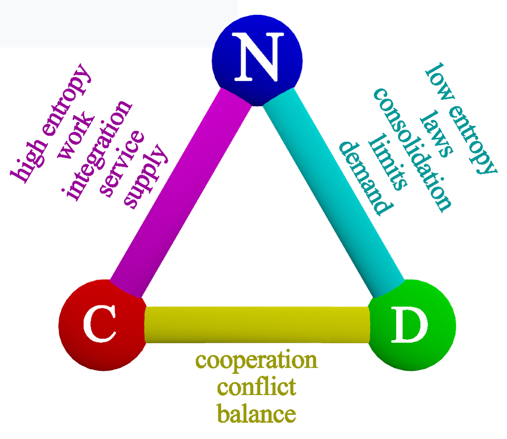

Now that we have mapped the three properties of Negotiation, Definition, and Contribution onto a trigram, we can see and label a new class of attributes that result from these properties interacting with each other. What would we expect to see across the spectrum between these points?

- **Negotiation/Definition**: This is the spectrum of **laws, rules, limits, demand**. Nothing can exist without definitions, limits, and rules, whether imposed by nature or by other systems such as society. In the context of human interactions, this describes how we agree on laws, rules, and limits. This spectrum also applies to the demand side of supply and demand, as demand for something acts as the limiting factor for its usability.
- **Definition/Contribution**: This is the spectrum of **cooperation and conflict**. Here is where two opposing concepts of restriction and expansion, low and high entropy, interact with one another. How something is defined and what it instantiates as are two different things. The path to expressing that definition requires integration with its environment, which can be cooperative or competitive.
- **Contribution/Negotiation**: This is the spectrum of **work, enablement, service, supply**. Society, as an organism in its own right, has certain needs that must be met to survive, and it is the responsibility of its members to address them. This spectrum also represents the supply side of supply and demand, as production is a contributing factor that involves work, provides a service, and enables further growth.

This trigram of relationships is present in every instance of creation and will be expressed in accordance with the context and scope of its instantiation.

In the context of society, we have *laws* (Negotiation/Definition), *cooperation and conflict* (Definition/Contribution), and *service and supply* (Contribution/Negotiation). Social theory, such as Adam Smith’s *Theory of the Invisible Hand*[^3], is predicated on the idea of cooperation based on voluntary exchange that benefits both parties as well as society.

In the context of the atomic world, the same three spectrums appear. *Laws* would refer to the limits that an atom must exist within. *Cooperation and conflict* could describe how the atom’s negative and positive forces work with and against each other, or how atoms fuse in nuclear fusion or break apart in nuclear fission. *Service and supply* describes the aspects of an atom that contribute to or enable the properties of its parent tholon, the realm from which it was created. In the tholonic view, this would be the realm of subatomic particles such as electrons, protons, and neutrons. How useful would subatomic particles be if there were no atoms?

#### **Key 66:** Stable patterns and instances form dynamic relationships and movement of energy, which form stable patterns and instances.

### Simple Instance

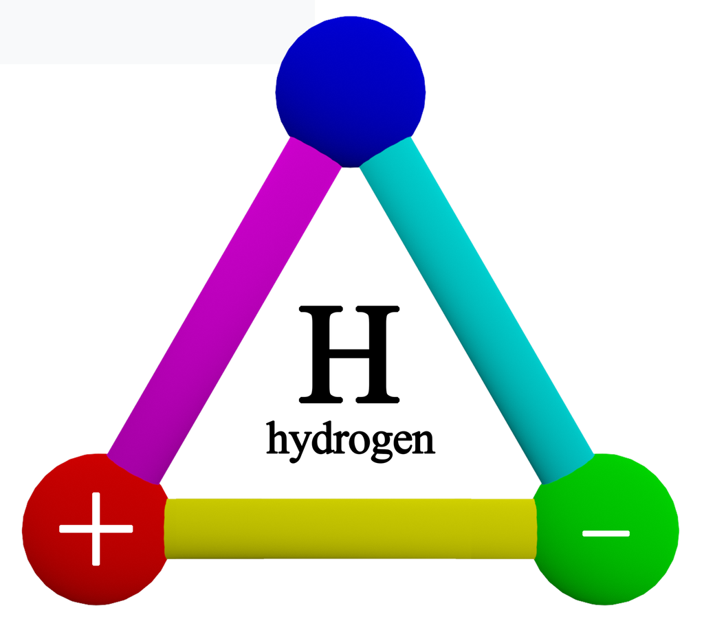

What is especially relevant is that hydrogen does *not* contain a neutron. From the tholonic perspective, this is precisely what we would expect, as the *Negotiated Balance* state, being a 0-dimensional point, does not actually exist physically (other than as a concept). Hydrogen with a neutron does exist and is called *deuterium*, representing a more stable, balanced version of the element. However, the fact that the most basic, fundamental, and abundant element in existence, and the element from which all other elements are created, lacks this physical manifestation of the Balance point strongly supports the tholonic model.

On the biological level, this same pattern appears in sexual reproduction. The maternal DNA provides one set of genetic information (*Definition*), establishing half of the constraints and limitations that define what the offspring can be. The paternal DNA provides the complementary set (*Contribution*), contributing the other half and enabling new genetic combinations through recombination. The offspring (*Negotiated Balance*) represents a unique individual that emerges from the interaction of these two sources, possessing traits that did not exist in exactly this combination in either parent. Just as hydrogen combines a proton and an electron to form the first element, sexual reproduction combines two distinct genetic sources to create a new life that is neither parent, yet draws from both.

In the realm of philosophy, this same pattern appears in the historical development of epistemology. Rationalism, exemplified by Descartes and Leibniz, argued that knowledge is *defined* by reason and innate ideas (*Definition*), establishing the constraint that true knowledge must be derived through logical deduction. Empiricism, championed by Locke and Hume, argued that sensory experience *contributes* all knowledge (*Contribution*), asserting that the mind begins as a blank slate filled only through observation. Kant’s Critical Philosophy emerged as a *Negotiated Balance* between these opposing positions, demonstrating that both reason and experience are necessary for knowledge, that neither alone is sufficient, and that their interaction produces our understanding of reality. This synthesis created a new philosophical framework that transcended both rationalism and empiricism while incorporating essential elements of each.

More generally, this pattern reflects the Hegelian Dialectic of thesis, antithesis, and synthesis. In fact, for any tholonic concept to exist as a potentially viable and sustainable expression, it must satisfy this form, supporting a thesis (D), antithesis (C), and synthesis (N) that emerges from the interaction of D and C.

Hegel’s own *Philosophy of Right*[^4] provides a direct illustration. The State (N) is the rational institution that mediates between the two opposing forces below it, making both coherent and sustainable through their ongoing resolution. It does not impose itself from outside the system; it emerges necessarily from the tension between the poles it balances. The Family (D) is the thesis: the immediate ethical unit of society, grounded in love and blood, which defines and constrains identity before any individual choice is possible. You are born into a family; it establishes who you are at the most fundamental level, setting the limits within which your social existence begins. Civil Society (C) is the antithesis: the marketplace of particular interests, the arena in which individuals go out into the world, contribute their labour and skills, and pursue their own ends in competition and cooperation with others. Left to itself, Civil Society fragments into atomism; left to itself, the Family closes into insularity. The State (N) is the synthesis that holds the tension between them, drawing on the intimacy and ethical immediacy of the Family while preserving the freedom and particularity of Civil Society, producing a social order that neither pole could sustain alone.

What makes this example especially precise from a tholonic perspective is that the State does not emerge directly from the raw opposition of Family and Civil Society. Along the spectrum between D and C, stable N-children first appear in the form of what Hegel calls Corporations: professional associations, guilds, trade unions, and civic organizations. The Corporation is exactly the intermediate institution the tholonic model would predict. From the Family (D) it inherits solidarity, mutual obligation, and a shared identity; from Civil Society (C) it inherits economic purpose and public engagement. It is neither Family nor Civil Society, but a stable resolution of their tension. Hegel himself argues that the State could not exist without Corporations as intermediaries, a claim that maps directly onto the tholonic principle that N-children must first stabilize along the D-C spectrum before a full N-source can emerge at the next scale. The complete sequence is therefore Family (D), Civil Society (C), Corporation (N-child), and State (N-source): a tholonic progression that Hegel arrived at through pure philosophical reasoning, without any knowledge of the model that would later describe it.

[figure not shown]

In chemistry, this pattern appears in the pH scale, which measures the concentration of hydrogen ions in a solution. Acids (*Definition*) represent one extreme, with high concentrations of hydrogen ions that constrain and limit what chemical reactions can occur (pH 0-6). Bases or alkalies (*Contribution*) represent the opposing extreme, with low hydrogen ion concentrations that enable different sets of reactions (pH 8-14). Neutral solutions (*Negotiated Balance*) exist at pH 7, where the concentration of hydrogen ions equals the concentration of hydroxide ions, creating a balanced state. Water, the foundation of most life, has a neutral pH of 7. The more complex the life-form, the more precisely it requires a balanced pH, as deviations in either direction limit the range of biochemical processes that can occur. When acids and bases are combined, they interact to reach a stable equilibrium, releasing energy as they move toward neutrality.

There are countless instances of nature and reality following this most fundamental pattern.

One detail is important before moving on. The initial 0-dimensional blue dot, which we call the **N-source** (Negotiation source), is the originating point and the only point able to replicate itself. Why this is so will be explained shortly.

The N-source operates in two modes: as an active process seeking equilibrium, or as a stable achieved state that serves as a template for generating new patterns. When actively negotiating, it has a dimensional form and a contextual instance. When balanced, it becomes a 0-dimensional concept that can propagate across scales.

When an N-source creates the Definition (D) and Contribution (C) points, these two points interact with each other along the spectrum between them. From this interaction, a new negotiated state emerges, which we call an **N-child**. The N-child appears on the line connecting D and C (as shown in earlier diagrams by the small blue dot on the yellow line). This N-child represents a new instance of balance specific to that particular D-C interaction. When the N-child becomes stable enough, it can mature into a full N-source capable of generating its own D and C points, continuing the pattern across scales. This is how the tholonic structure replicates and propagates throughout reality.

### House of Mirrors

Within the trigram, there is energy, and therefore movement, and therefore patterns and oscillations. From these dynamics, stable states arise that are sustainable enough to become new N-children, which can mature into full N-sources. Even though one particular N-child will exist at a specific point on the spectrum between C and D, all possible states collectively cover the entire range between C and D. We can generally predict where along this spectrum various states will arise by applying a normal distribution.

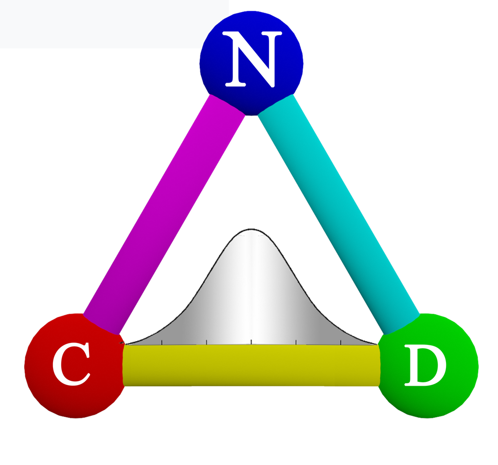

The image on the right shows a Bell curve within the trigram to illustrate where along the CD spectrum stable instances will most likely occur. The yellow line connecting C and D represents the field of interaction between them. This is where new N-children emerge from the negotiation between Definition and Contribution. When an N-child becomes stable enough, it can mature into a full N-source capable of generating its own patterns.

We can now describe the three fundamental points of a tholonic trigram more clearly:

- **N** (Negotiation) corresponds to the 1<sup>st</sup> blue dot

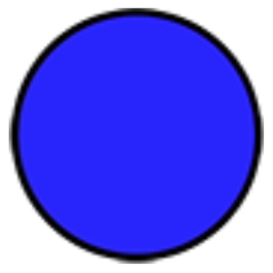

  , the N-source, which represents awareness of a concept in its simplest form.
- **D** (Definition) corresponds to the 2<sup>nd</sup> green dot

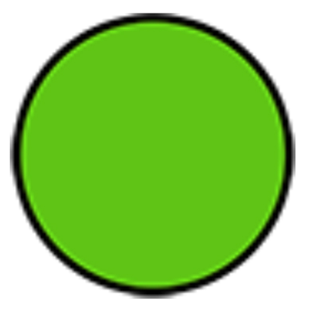

  , which introduces limitation, division, and separation.
- **C** (Contribution) corresponds to the 3<sup>rd</sup> red dot

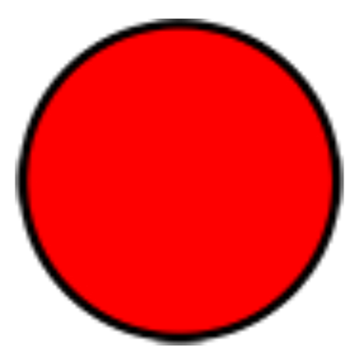

  , which provides expansion and integration. Together, D and C interact to create N-children, enabling unification and form.

By these descriptions, we can describe a general process that defines creation as something like:

> The cooperative or conflicted merging of contrasting concepts that finds a balanced (Negotiated) expression in form (Contribution) through limitation, division, and separation (Definition).

At the most abstract levels, this describes the Big Bang, biological reproduction, the laws of physics, philosophy, and anything else that exists within a duality.

What this chapter has established is the formal architecture of the tholonic model: the N-D-C pattern, the geometry of how a 0-dimensional point of A&I unfolds into a tetrahedron of four qualitatively distinct points, and the thologram as a fractal hierarchy organised by the movement of energy rather than by the things that energy moves through. The tholon is not a physical object but a pattern of relationships, and any system at any scale that instantiates those relationships, from hydrogen to a civilisation, is a tholon.

The next chapter examines the thologram as a whole: its tetrahedral structure, the geometric demonstration of how energy propagates between parent and child tholons through the structural channels the tholonic model calls *tholonic paths*, and how the resulting patterns appear in measurable physical reality from the quantum scale to the cosmological. The tholon explained what the unit is. The thologram explains what the universe looks like when you fill it with them.

[^1]: Exodus 3:14 “And God said to Moses, ‘Ehyeh-Asher-Ehyeh,’ *(‘Ehyeh-Asher-Ehyeh’ Meaning of Heb. uncertain; variously translated: ”I Am That I Am”; ”I Am Who I Am”; ”I Will Be What I Will Be”; and more.)* ‘Thus shall you say to the Israelites, ’Ehyeh *(“Ehyeh” meaning “I Am” or “I Will Be.”)* sent me to you.’”,
[^2]: “**Reciprocal Theory**” RationalWiki, https://rationalwiki.org/wiki/Reciprocal_Theory.
[^3]: Adam Smith, “An Inquiry into the Nature and Causes of the Wealth of Nations”, 1776, London
[^4]: Hegel, G.W.F., *Elements of the Philosophy of Right* (*Grundlinien der Philosophie des Rechts*), 1820, Berlin. The tripartite structure of Ethical Life (Sittlichkeit) — Family (§§ 158–181), Civil Society (§§ 182–256), and State (§§ 257–360) — with Corporations as the mediating institution (§§ 250–256), is found in Part Three. English translation: H.B. Nisbet, ed. Allen W. Wood, Cambridge University Press, 1991.